# Week_5_KMeans

### KMeans Clustering

```python
# Standard imports
import numpy as np
import pandas as pd
import matplotlib.pyplot as plt
import seaborn as sns

import warnings
warnings.filterwarnings("ignore")
```

```python
#import the Iris dataset from Canvas with pandas
dataset = pd.read_csv('LPGA Data_labels.csv')
```

```python
dataset.head(10)
```

|  | Golfer id 4-8 | average drive (yards) 10-16 | percent of fairways hit 18-24 | percent of greens reached in regulation 26-32 | average putts per round 34-40 | percent of sand saves (2 shots to hole) 42-48 | prize winnings ($1000s) 50-56 | ln(prize) 58-64 | tournaments played in 70-72 | green in regulation putts per hole 55-80 | completed tournaments 86-88 | average percentile in tournaments (high is good) 90-96 | rounds completed 100-104 | average strokes per round 106-112 |
| --- | --- | --- | --- | --- | --- | --- | --- | --- | --- | --- | --- | --- | --- | --- |
| 0 | 1 | 251.0 | 73.8 | 64.7 | 29.35 | 36.5 | 202624 | 12.22 | 20 | 1.79 | 13 | 55.18 | 61 | 72.492 |
| 1 | 2 | 256.7 | 73.3 | 69.6 | 29.71 | 30.2 | 385270 | 12.86 | 20 | 1.78 | 14 | 66.57 | 65 | 71.477 |
| 2 | 3 | 250.1 | 65.9 | 64.1 | 29.43 | 32.7 | 125894 | 11.74 | 18 | 1.78 | 12 | 55.50 | 56 | 72.250 |
| 3 | 4 | 252.6 | 64.5 | 66.2 | 30.33 | 37.5 | 324460 | 12.69 | 20 | 1.84 | 15 | 56.89 | 65 | 72.646 |
| 4 | 5 | 259.2 | 65.5 | 62.7 | 30.26 | 42.3 | 37230 | 10.52 | 16 | 1.87 | 7 | 41.95 | 45 | 73.444 |
| 5 | 6 | 249.9 | 74.8 | 66.2 | 31.11 | 27.3 | 26408 | 10.18 | 17 | 1.89 | 5 | 38.24 | 42 | 73.548 |
| 6 | 7 | 252.4 | 60.2 | 57.5 | 28.90 | 50.0 | 86486 | 11.37 | 21 | 1.79 | 11 | 44.50 | 61 | 73.213 |
| 7 | 8 | 256.8 | 71.9 | 69.1 | 31.45 | 43.2 | 115475 | 11.66 | 20 | 1.89 | 11 | 52.54 | 58 | 72.759 |
| 8 | 9 | 245.4 | 67.3 | 56.4 | 29.91 | 32.5 | 4328 | 8.37 | 17 | 1.87 | 2 | 27.37 | 37 | 74.892 |
| 9 | 10 | 247.9 | 73.3 | 61.4 | 29.96 | 36.7 | 43361 | 10.68 | 11 | 1.86 | 3 | 39.57 | 27 | 73.370 |

```python
features = ['average drive (yards)   10-16',
       'percent of fairways hit   18-24',
       'percent of greens reached in regulation   26-32',
       'average putts per round    34-40',
       'percent of sand saves (2 shots to hole)   42-48',
       'prize winnings ($1000s)    50-56', 'ln(prize)    58-64',
       'tournaments played in    70-72',
       'green in regulation putts per hole   55-80',
       'completed tournaments   86-88',
       'average percentile in tournaments (high is good)   90-96',
       'rounds completed     100-104',
       'average strokes per round     106-112']
```

```python
# dataset.columns
```

#### Study Correlation

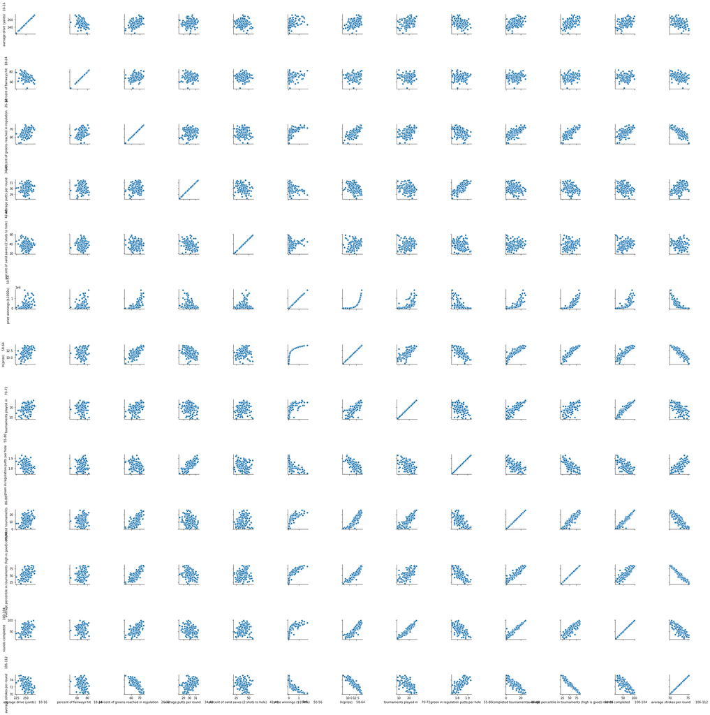

```python
# from pandas.plotting import scatter_matrix
import seaborn as sns
g = sns.PairGrid(dataset[features])
g.map(sns.scatterplot)
```

```python
features2 = [
        'percent of fairways hit   18-24',
       'percent of greens reached in regulation   26-32',
       'average putts per round    34-40',
       'percent of sand saves (2 shots to hole)   42-48',
       'prize winnings ($1000s)    50-56', 'ln(prize)    58-64',
       'tournaments played in    70-72',
       'green in regulation putts per hole   55-80']
```

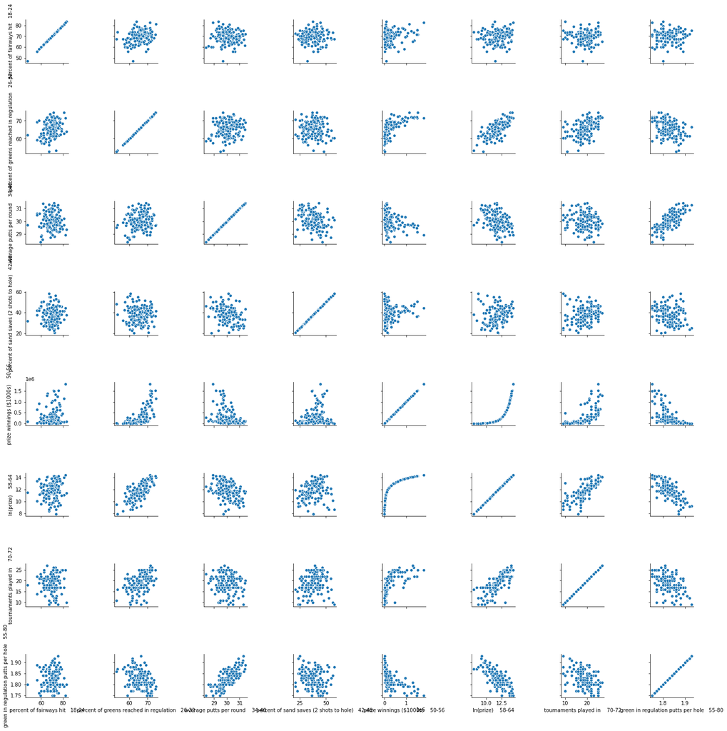

```python
g = sns.PairGrid(dataset[features2])
g.map(sns.scatterplot)
```

## Clustering - KMeans

Cluster finding initially seekd to find $N$ clusters in a data set and to subsequently identify which data points belong to each cluster. While there are a number of different approaches to clustering, one of the easiest to understand is the k-means algorithm.

#### Manhattan Distance

- The taxicab distance between two vectors p,q in an n-dimensional real vector space with fixed Cartesian coordinate system, is the sum of the lengths of the projections of the line segment between the points onto the coordinate axes.
- Sum of abs value of difference between vector p and q

#### Euclidean Distance

- sqrt of sum of square of (difference between vector p and q)

```python
x =  dataset[features2]
```

#### Scale the data -

1. StandardScaler
2. MinMaxScaler
   - Many machine learning algorithms require that features are on the same scale
   - Features may have very different variances!
   - Variance of a feature measures may spread of its values
   - In kmeans : feature variance = feature influence
   - StandardScaler transforms each feature to have mean 0 and variance 1 Standardization
   - MinMaxScaler scales each input variable separately to the range 0 1 Normalization

```python
# split data into training and testing and scale using Minmax scaling
from sklearn.preprocessing import MinMaxScaler, StandardScaler
scaler  = StandardScaler()
scaler.fit(x) # fit the data
x_scale = scaler.transform(x) # transform the data
```

#### Find an optimum K

1. From Elbow curve -
   - Distortion: It is calculated as the average of the squared distances from the cluster centers of the respective clusters. Typically, the Euclidean distance metric is used.
   - Inertia: It is the sum of squared distances of samples to their closest cluster center.

[figure not shown]

```python
#Let's select the optimum number of clusters for k-means classification
from sklearn.cluster import KMeans
wcss = []

for i in range(2, 7):
    kmeans = KMeans(n_clusters = i, init = 'k-means++',
                    max_iter = 100, n_init = 10, random_state = 10) # fitting my first k
    kmeans.fit(x_scale)
    wcss.append(kmeans.inertia_)
    #r-square= betweeness

#Plotting the results onto a line graph to observe 'The elbow'
plt.plot(range(2, 7), wcss)
plt.title('Elbow Method')
plt.xlabel('Association')# between clster sum of square
plt.ylabel('WCSS') #within cluster sum of squares
plt.show()
```

## Fit clusters with optimum K

```python
kmeans = KMeans(n_clusters = 3, init = 'k-means++', max_iter = 500,
                n_init = 10, random_state = 0)
label  = kmeans.fit_predict(x_scale)
```

```python
label
```

```
array([1, 1, 1, 1, 2, 2, 1, 2, 2, 2, 1, 2, 1, 2, 1, 1, 0, 1, 1, 0, 2, 2,
       1, 2, 2, 2, 1, 2, 1, 2, 1, 1, 2, 1, 1, 2, 2, 2, 1, 0, 1, 0, 2, 0,
       1, 2, 2, 1, 1, 2, 0, 1, 1, 1, 1, 1, 1, 2, 1, 0, 2, 1, 1, 1, 1, 0,
       2, 1, 0, 1, 1, 1, 2, 0, 1, 2, 0, 0, 1, 2, 0, 1, 0, 1, 1, 2, 2, 1,
       1, 2, 1, 2, 1, 2, 2, 0, 0, 1, 2, 1, 1, 2, 0, 0, 0, 2, 2, 1, 1, 0,
       1, 1, 1, 0, 1, 0, 1, 2, 1, 1, 1, 1, 0, 1, 1, 2, 2, 2, 0, 1, 1, 1,
       2, 0, 1, 1, 0, 0, 2, 2, 2, 0, 1, 1, 2, 0])
```

### Unscale your data to interpret centroids

```python
train_centroids_unscale = pd.DataFrame(scaler.inverse_transform(kmeans.cluster_centers_))
train_centroids_unscale.columns = x.columns
train_centroids_unscale
```

|  | percent of fairways hit 18-24 | percent of greens reached in regulation 26-32 | average putts per round 34-40 | percent of sand saves (2 shots to hole) 42-48 | prize winnings ($1000s) 50-56 | ln(prize) 58-64 | tournaments played in 70-72 | green in regulation putts per hole 55-80 |
| --- | --- | --- | --- | --- | --- | --- | --- | --- |
| 0 | 69.354000 | 62.952000 | 30.533200 | 35.550000 | 44492.200000 | 10.347600 | 15.640000 | 1.865600 |
| 1 | 72.757692 | 70.542308 | 29.647308 | 42.019231 | 976795.076923 | 13.715385 | 23.500000 | 1.786923 |
| 2 | 68.717143 | 65.532857 | 29.814857 | 37.928571 | 217769.114286 | 12.099286 | 19.628571 | 1.812429 |

## Cluster Visualization

[figure not shown]

```python
#Color the dataset based on the label and plot
plt.scatter(x_scale[labels == 0, 0], x_scale[labels == 0, 1], s = 75,
            c = 'red', label = 'cluster0')
plt.scatter(x_scale[labels == 1, 0], x_scale[labels == 1, 1], s = 75,
            c = 'blue', label = 'cluster1')
plt.scatter(x_scale[labels == 2, 0], x_scale[labels == 2, 1], s = 75,
            c = 'green', label = 'cluster2')

#Plotting the centroids of the clusters
plt.scatter(kmeans.cluster_centers_[:,0],
            kmeans.cluster_centers_[:,1], s = 100,
            c = 'yellow', label = 'Centroide')
```

## Interpretation of cluster

```python
# Business interpretation
# statistically - Cluster size, centroids
```